# RBIF111 - Homework 3

Neshita Kipuw

2024-10-28

```r
# Load necessary packages
library(ggplot2)
library(tidyr)
library(dplyr)
library(stats)
library(DESeq2)
library(reshape2)
library(data.table)
library(cowplot)
```

The following RNAseq data set is obtained from GEO accession **GSE248274**. It is a study of the mechanisms involved in colonic epithelial differentiation that is key to unraveling the alterations causing inflammatory conditions and colon cancer. The researchers performed global transcriptomic analyses (RNA-seq) in colon normal organoids derived from 6 patients that were incubated in proliferation medium or differentiation medium, containing Bone Morphogenetic Protein 4 and the Notch inhibitor dibenzazepine, for 48 h. Additionally, organoids cultured in differentiation medium were treated with calcitriol or ethanol (control) to investigate the effect of vitamin D on the differentiation of colon normal organoids. *Note*: code is hidden due to extensive lines of code.

```r
GEODataDownload <- function(DS, gpl, gsm, PlateAnnotInfo, GenerateMetaData, Technology){
  library(DESeq2); library(limma); library(data.table)
  if(Technology == "Array"){
    gset <- getGEO(DS)
    if(length(gset) > 1) idx <- grep(gpl, attr(gset, "names")) else idx <- 1
    gset <- gset[[idx]]
    fvarLabels(gset) <- make.names(fvarLabels(gset))
    comp <- gsub(" ", "", gsm)
    comp <- gsub(",", "", comp)
    gsms <- paste0(comp)
    #### Set up raw names ####
    sml <- c()
    for(i in 1:nchar(gsms)){ sml[i] <- substr(gsms,i,i)}
    ex <- exprs(gset)
    qx <- as.numeric(quantile(ex, c(0., 0.25, 0.5, 0.75, 0.99, 1.0), na.rm=T))
    LogC <- (qx[5] > 100) ||
      (qx[6]-qx[1] > 50 && qx[2] > 0) ||
      (qx[2] > 0 && qx[2] < 1 && qx[4] < 2)
    if(LogC){ ex[which(ex <= 0)] <- NaN
    exprs(gset) <- log2(ex) }
    sml <- paste("G", sml, sep="")
    f1 <- as.factor(sml)
    gset$description2 <- f1
    design <- model.matrix(~description2 + 0, gset)
    colnames(design) <- levels(f1)
    fit <- lmFit(gset, design)
    cont.matrix <- makeContrasts(G1-G0, levels = design)
    fit2 <- contrasts.fit(fit, cont.matrix)
    fit2 <- eBayes(fit2, 0.01)
    tT <- topTable(fit2, adjust="fdr", sort.by = "B", number = 25000000000)
    #### subset ####
    ex2 <- data.table(subset(tT, select=c("ID", "logFC", "P.Value", "adj.P.Val")))
    ex2$ID <- as.character(ex2$ID)
    #### annotate with gene names ####
    plat <- PlateAnnotInfo[GPLID == gpl,][,!"GPLID", with = FALSE]
    if(nrow(plat) == 0){ print(paste("There is no annotation information available for", gpl)) }
    plat$ID <- as.character(plat$ID)
    plat <- plat[!duplicated(plat$ID),]
    ex2 <- merge(plat, ex2, by = "ID")
    ex2$ID <- as.character(ex2$ID)
    exraw <- data.table(ex)
    exraw$ID <- as.character(rownames(ex))
    #### annotate raw data with gene names ####
    ex2 <- merge(ex2, exraw, by = "ID")
    #### Generate Meta Data ####
    Pdat <- pData(gset)
    #### Add Meta data ####
    Pdat <- as.data.table(Pdat)
    return(list(Data = ex2, MetaData = Pdat))
  }

  if(Technology == "RNAseq"){
    ACC <- paste("acc=", DS, sep = "")
    file <- paste("file=", DS, "_raw_counts_GRCh38.p13_NCBI.tsv.gz", sep = "")
    comp <- gsub(" ", "", gsm)
    comp <- gsub(",", "", comp)
    gsms <- paste0(comp)
    #### Set up DEG names ####
    urld <- "https://www.ncbi.nlm.nih.gov/geo/download/?format=file&type=rnaseq_counts"
    path <- paste(urld, ACC, file, sep="&");
    tbl <- as.matrix(data.table::fread(path, header=T, colClasses="integer"), rownames="GeneID")
    exraw <- tbl
    apath <- paste(urld, "type=rnaseq_counts", "file=Human.GRCh38.p13.annot.tsv.gz", sep="&")
    annot <- data.table::fread(apath, header=T, quote="", stringsAsFactors=F, data.table=F)
    rownames(annot) <- annot$GeneID
    sml <- strsplit(gsms, split="")[[1]]
    sel <- which(sml != "X")
    sml <- sml[sel]
    tbl <- tbl[ ,sel]
    gs <- factor(sml)
    groups <- make.names(c("Ctrl", "Tx"))
    levels(gs) <- groups
    sample_info <- data.frame(Group = gs, row.names = colnames(tbl))
    keep <- rowSums( tbl >= 10 ) >= min(table(gs))
    tbl <- tbl[keep, ]
    ds <- DESeqDataSetFromMatrix(countData=tbl, colData=sample_info, design= ~Group)
    ds <- DESeq(ds, test="Wald", sfType="poscount")
    r <- results(ds, contrast=c("Group", groups[2], groups[1]), alpha=0.05, pAdjustMethod ="fdr")
    tT <- r[order(r$padj)[1:length(r$padj)],]
    tT <- merge(as.data.frame(tT), annot, by=0, sort=F)
    tT <- subset(tT, select=c("GeneID","padj","pvalue","lfcSE","stat","log2FoldChange","baseMean","Symbol","Description"))
    #### subset ####
    ex2 <- data.table(subset(tT, select=c("GeneID", "Symbol", "Description", "log2FoldChange", "pvalue", "padj")))
    #### Adjust column names ####
    setnames(ex2, c("GeneID", "Symbol", "Description"), c("ENTREZID", "SYMBOL", "GENENAME"))
    #### Get Raw data ####
    GeneID <- as.integer(rownames(exraw))
    exraw <- as.data.table(exraw)
    #### Update column names ####
    exraw$ENTREZID <- GeneID
    #### merge FC and raw data together ####
    mer <- merge(ex2, exraw, by = "ENTREZID")
    return(mer)
  }
}
#### Execute the GEODataDownload function and obtain the RNAseq data set ####
RNAseqData <- GEODataDownload(DS = "GSE248274",
                              gpl = "GPL21697",
                              gsm = "01001001010101",
                              PlateAnnotInfo = "Only needed if the data was generated using MicroArrays",
                              GenerateMetaData = "Only needed if the data was generated using MicroArrays",
                              Technology = "RNAseq")
data.table(head(as.data.frame(RNAseqData),10), filter = 'top', options = list(pageLength = 10, scrollX = TRUE, scrollY = "400px", autoWidth = TRUE))
```

```
##     ENTREZID   SYMBOL                                  GENENAME log2FoldChange
##        <int>   <char>                                    <char>          <num>
##  1:        9     NAT1                     N-acetyltransferase 1     0.55574809
##  2:       10     NAT2                     N-acetyltransferase 2     0.48539401
##  3:       12 SERPINA3                  serpin family A member 3    -1.62754834
##  4:       13    AADAC                 arylacetamide deacetylase     0.61188301
##  5:       14     AAMP   angio associated migratory cell protein    -0.01565966
##  6:       16    AARS1                  alanyl-tRNA synthetase 1    -0.08440810
##  7:       18     ABAT          4-aminobutyrate aminotransferase     0.41656857
##  8:       19    ABCA1 ATP binding cassette subfamily A member 1    -0.48885458
##  9:       20    ABCA2 ATP binding cassette subfamily A member 2    -0.52195209
## 10:       21    ABCA3 ATP binding cassette subfamily A member 3    -0.19685132
##         pvalue      padj GSM7910769 GSM7910771 GSM7910772 GSM7910773 GSM7910774
##          <num>     <num>      <int>      <int>      <int>      <int>      <int>
##  1: 0.19140583 0.9648710          6         29         28         37         61
```

[output cut: 33 more lines]

File was downloaded and saved into the current working directory under a new name, and reloaded into R environment.

```r
####Define file path to save into working directory####
#getwd()
#file_path <- "~/RBIF111"

####Save the RNAseq data set to the working directory####
saveRDS(RNAseqData, file = "RNAseq_GSE248274.rds")

####Reload the file into R environment####
RNAseq_GSE248274 <- readRDS("RNAseq_GSE248274.rds")
print(head(RNAseq_GSE248274))
```

```
## Key: <ENTREZID>
##    ENTREZID   SYMBOL                                GENENAME log2FoldChange
##       <int>   <char>                                  <char>          <num>
## 1:        9     NAT1                   N-acetyltransferase 1     0.55574809
## 2:       10     NAT2                   N-acetyltransferase 2     0.48539401
## 3:       12 SERPINA3                serpin family A member 3    -1.62754834
## 4:       13    AADAC               arylacetamide deacetylase     0.61188301
## 5:       14     AAMP angio associated migratory cell protein    -0.01565966
## 6:       16    AARS1                alanyl-tRNA synthetase 1    -0.08440810
##        pvalue      padj GSM7910769 GSM7910771 GSM7910772 GSM7910773 GSM7910774
##         <num>     <num>      <int>      <int>      <int>      <int>      <int>
## 1: 0.19140583 0.9648710          6         29         28         37         61
## 2: 0.38729351 0.9648710         19         65          7         32         15
## 3: 0.02119953 0.9648710          2          0         21         14          4
## 4: 0.52827933 0.9677374          1         11          3          7         10
```

[output cut: 18 more lines]

Added new columns called age, sex, group, and Subset_Comparison for sample annotation

```r
####Create a new data frame to group the samples by ctrl vs. Tx ####
new_df <- data.frame(
  Sample_ID = c("GSM7910769", "GSM7910771", "GSM7910772", "GSM7910773", "GSM7910774", "GSM7910775", "GSM7910776", "GSM7910777", "GSM7910778", "GSM7910780", "GSM7910782", "GSM7910783", "GSM7910785", "GSM7910786"),
  group = c("Ctrl", "Tx", "Ctrl", "Ctrl", "Tx", "Ctrl", "Ctrl", "Tx", "Ctrl", "Tx", "Ctrl", "Tx", "Ctrl", "Tx"),
  age = c(58,58,55,55,55,64,64,64,71,71,88,88,68,68),
  sex = c("M","M","M","M","M","M","M","M","F","F","F","F","M","M")
)

#### Convert data set to long format to merge the sample group####
RNAseq_GSE248274_2 <- melt(RNAseq_GSE248274, id.vars = c("ENTREZID", "SYMBOL", "GENENAME", "log2FoldChange", "pvalue", "padj"),
                           variable.name = "Sample_ID", value.name = "Expression")

####Merge the sample group to the long format data set and append the new column ####
RNAseq_GSE248274_2 <- merge(RNAseq_GSE248274_2, new_df, by = "Sample_ID", all.x = TRUE)

####Append the new column and use a placeholder value####
RNAseq_GSE248274_2$Subset_Comparison <- "Unknown"

####Annotate the samples with correct sample groups####
RNAseq_GSE248274_2$Subset_Comparison <- ifelse(RNAseq_GSE248274_2$group == "Tx", "Treatment", "Control")

####Check the resulting converted data set####
print(head(RNAseq_GSE248274_2))
```

```
## Key: <Sample_ID>
##     Sample_ID ENTREZID   SYMBOL                                GENENAME
##        <char>    <int>   <char>                                  <char>
## 1: GSM7910769        9     NAT1                   N-acetyltransferase 1
## 2: GSM7910769       10     NAT2                   N-acetyltransferase 2
## 3: GSM7910769       12 SERPINA3                serpin family A member 3
## 4: GSM7910769       13    AADAC               arylacetamide deacetylase
## 5: GSM7910769       14     AAMP angio associated migratory cell protein
## 6: GSM7910769       16    AARS1                alanyl-tRNA synthetase 1
##    log2FoldChange     pvalue      padj Expression  group   age    sex
##             <num>      <num>     <num>      <int> <char> <num> <char>
## 1:     0.55574809 0.19140583 0.9648710          6   Ctrl    58      M
## 2:     0.48539401 0.38729351 0.9648710         19   Ctrl    58      M
## 3:    -1.62754834 0.02119953 0.9648710          2   Ctrl    58      M
## 4:     0.61188301 0.52827933 0.9677374          1   Ctrl    58      M
## 5:    -0.01565966 0.94975576 0.9954194        268   Ctrl    58      M
## 6:    -0.08440810 0.77433916 0.9850861       1656   Ctrl    58      M
##    Subset_Comparison
##               <char>
## 1:           Control
## 2:           Control
## 3:           Control
## 4:           Control
## 5:           Control
## 6:           Control
```

```r
print(tail(RNAseq_GSE248274_2))
```

```
## Key: <Sample_ID>
##     Sample_ID  ENTREZID          SYMBOL                             GENENAME
##        <char>     <int>          <char>                               <char>
## 1: GSM7910786 114108587       ATF7-NPFF                ATF7-NPFF readthrough
## 2: GSM7910786 114118903  ARHGAP11A-SCG5           ARHGAP11A-SCG5 readthrough
## 3: GSM7910786 114483834     ABCF2-H2BK1              ABCF2-H2BK1 readthrough
## 4: GSM7910786 114841035    LOC114841035 Uncharacterized protein LOC114841035
## 5: GSM7910786 115072896 SLCO1B3-SLCO1B7          SLCO1B3-SLCO1B7 readthrough
## 6: GSM7910786 115253422    DUS4L-BCAP29             DUS4L-BCAP29 readthrough
##    log2FoldChange      pvalue      padj Expression  group   age    sex
##             <num>       <num>     <num>      <int> <char> <num> <char>
## 1:    0.001227667 0.997019767 0.9995337         14     Tx    68      M
## 2:   -0.994760421 0.008918404 0.8575052         73     Tx    68      M
## 3:   -0.125430536 0.673587701 0.9755366         22     Tx    68      M
## 4:    0.179873937 0.427366974 0.9675872        629     Tx    68      M
## 5:   -0.288228917 0.668586852 0.9755366        141     Tx    68      M
## 6:    0.199860312 0.435138262 0.9675872        318     Tx    68      M
##    Subset_Comparison
##               <char>
## 1:         Treatment
## 2:         Treatment
## 3:         Treatment
## 4:         Treatment
## 5:         Treatment
## 6:         Treatment
```

# 1 Question 1

## 1.1 Finding genes with the most and least significant effect on the continuous variable (dependent variable).

The code below takes *age* as the continuous variable and *gene expression* as the independent variable. Then a linear model is fitted for each gene, and the ANOVA test was done to extract the p-values.

```r
set.seed(123)
#Create placeholder for p-values
gene_pvalues <- data.frame(SYMBOL = unique(RNAseq_GSE248274_2$SYMBOL), p_value = NA)

# Loop each gene then fit linear model and perform ANOVA test
gene_pvalues$p_value <- sapply(gene_pvalues$SYMBOL, function(gene) {
  # Subset the data for each gene
  gene_subset <- RNAseq_GSE248274_2[RNAseq_GSE248274_2$SYMBOL == gene, ]

  # Fit a linear model and perform ANOVA test
  anova_test <- anova(lm(age ~ Expression, data = gene_subset))

  # Return the p-value
  anova_test$`Pr(>F)`[1]
})

#Find genes with most and least significant effect
most_signif <- gene_pvalues[order(gene_pvalues$p_value), ]
least_signif <- gene_pvalues[order(gene_pvalues$p_value, decreasing = TRUE), ]

print(paste("Most significant gene based on ANOVA test is:", most_signif[1, "SYMBOL"], ", with p-value =", format(most_signif[1, "p_value"], scientific = TRUE)))
```

```
## [1] "Most significant gene based on ANOVA test is: PSMC4 , with p-value = 2.476589e-07"
```

```r
print(paste("Least significant gene based on ANOVA test is:", least_signif[1, "SYMBOL"], ", with p-value =", format(least_signif[1, "p_value"], scientific = TRUE)))
```

```
## [1] "Least significant gene based on ANOVA test is: PCSK9 , with p-value = 9.999269e-01"
```

The code below generates the p-value distribution for gene effect on age for all of the genes.

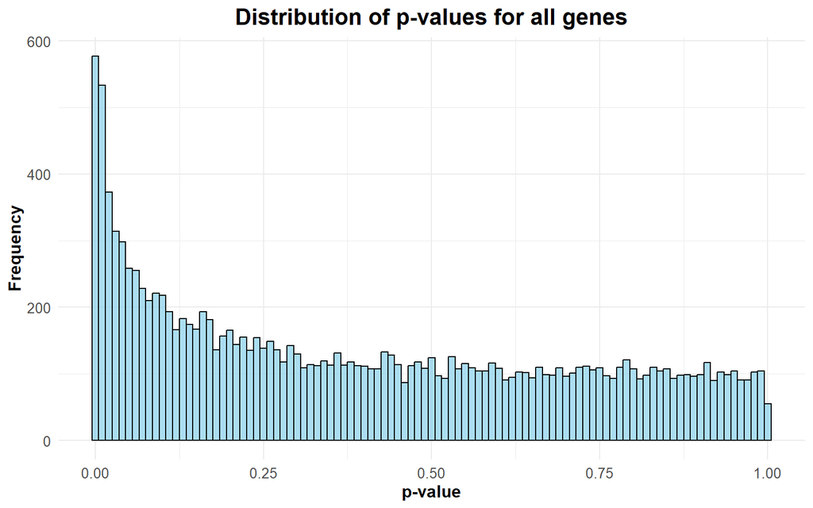

```r
ggplot(gene_pvalues, aes(x = p_value)) +
  geom_histogram(binwidth = 0.01, fill = "skyblue", color = "black", alpha = 0.7) +
  labs(title = "Distribution of p-values for all genes", x = "p-value", y = "Frequency") +
  theme_minimal() +
  theme(plot.title = element_text(size = 16, face = "bold", hjust = 0.5),
        axis.title = element_text(size = 12, face = "bold"),
        axis.text = element_text(size = 10))
```

The code below performs the linear model of the gene with the most and least significant effects.

```r
#Create models for most and least significant genes
most_signif_model <- lm(age ~ Expression, data = RNAseq_GSE248274_2[RNAseq_GSE248274_2$SYMBOL == most_signif[1, "SYMBOL"], ])
least_signif_model <- lm(age ~ Expression, data = RNAseq_GSE248274_2[RNAseq_GSE248274_2$SYMBOL == least_signif[1, "SYMBOL"], ])
```

This is the summary and ANOVA results for the linear models of the most significant gene

```r
summary(most_signif_model)
```

```
##
## Call:
## lm(formula = age ~ Expression, data = RNAseq_GSE248274_2[RNAseq_GSE248274_2$SYMBOL ==
##     most_signif[1, "SYMBOL"], ])
##
## Residuals:
##     Min      1Q  Median      3Q     Max
## -5.9093 -2.5532  0.4668  1.8472  6.0914
##
## Coefficients:
##              Estimate Std. Error t value Pr(>|t|)
## (Intercept) 28.435270   3.775005   7.533 6.93e-06 ***
## Expression   0.034418   0.003327  10.346 2.48e-07 ***
## ---
## Signif. codes:  0 '***' 0.001 '**' 0.01 '*' 0.05 '.' 0.1 ' ' 1
##
## Residual standard error: 3.583 on 12 degrees of freedom
## Multiple R-squared:  0.8992, Adjusted R-squared:  0.8908
## F-statistic:   107 on 1 and 12 DF,  p-value: 2.477e-07
```

```r
anova(most_signif_model)
```

```
## Analysis of Variance Table
##
## Response: age
##            Df  Sum Sq Mean Sq F value    Pr(>F)
## Expression  1 1374.29 1374.29  107.04 2.477e-07 ***
## Residuals  12  154.07   12.84
## ---
## Signif. codes:  0 '***' 0.001 '**' 0.01 '*' 0.05 '.' 0.1 ' ' 1
```

This is the summary and ANOVA results for the linear models of the least significant gene

```r
summary(least_signif_model)
```

```
##
## Call:
## lm(formula = age ~ Expression, data = RNAseq_GSE248274_2[RNAseq_GSE248274_2$SYMBOL ==
##     least_signif[1, "SYMBOL"], ])
##
## Residuals:
##     Min      1Q  Median      3Q     Max
## -11.215  -8.214  -2.214   4.036  21.786
##
## Coefficients:
##               Estimate Std. Error t value Pr(>|t|)
## (Intercept)  6.621e+01  7.818e+00   8.469 2.09e-06 ***
## Expression  -1.733e-06  1.853e-02   0.000        1
## ---
## Signif. codes:  0 '***' 0.001 '**' 0.01 '*' 0.05 '.' 0.1 ' ' 1
##
## Residual standard error: 11.29 on 12 degrees of freedom
## Multiple R-squared:  7.291e-10,  Adjusted R-squared:  -0.08333
## F-statistic: 8.749e-09 on 1 and 12 DF,  p-value: 0.9999
```

```r
anova(least_signif_model)
```

```
## Analysis of Variance Table
##
## Response: age
##            Df Sum Sq Mean Sq F value Pr(>F)
## Expression  1    0.0    0.00       0 0.9999
## Residuals  12 1528.4  127.36
```

The code below generates the diagnostic plots for the linear models of the gene with the most significant effects.

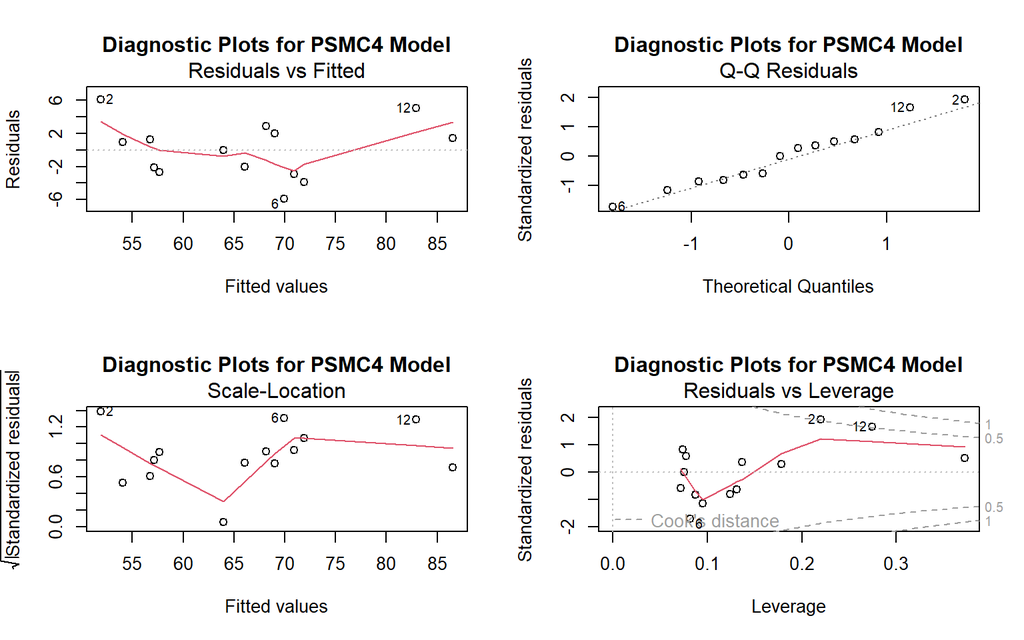

```r
par(mfrow = c(2, 2))
plot(most_signif_model, main = paste("Diagnostic Plots for", most_signif[1, "SYMBOL"], "Model"))
```

The code below generates the diagnostic plots for the linear models of the gene with the least significant effects.

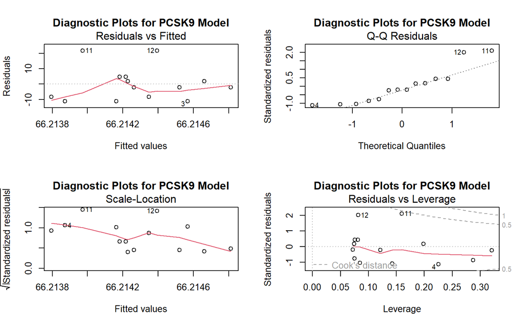

```r
par(mfrow = c(2, 2))
plot(least_signif_model, main = paste("Diagnostic Plots for", least_signif[1, "SYMBOL"], "Model"))
```

# 2 Question 2

```r
#Get data from GEO
GEODataDownload <- function(DS, gpl, gsm, PlateAnnotInfo, GenerateMetaData, Technology){
  library(DESeq2); library(data.table)
  if(Technology == "Array"){
    gset <- getGEO(DS)
    if(length(gset) > 1) idx <- grep(gpl, attr(gset, "names")) else idx <- 1
    gset <- gset[[idx]]
    fvarLabels(gset) <- make.names(fvarLabels(gset))
    comp <- gsub(" ", "", gsm)
    comp <- gsub(",", "", comp)
    gsms <- paste0(comp)
    #### Set up raw names ####
    sml <- c()
    for(i in 1:nchar(gsms)){ sml[i] <- substr(gsms,i,i)}
    ex <- exprs(gset)
    qx <- as.numeric(quantile(ex, c(0., 0.25, 0.5, 0.75, 0.99, 1.0), na.rm=T))
    LogC <- (qx[5] > 100) ||
      (qx[6]-qx[1] > 50 && qx[2] > 0) ||
      (qx[2] > 0 && qx[2] < 1 && qx[4] < 2)
    if(LogC){ ex[which(ex <= 0)] <- NaN
    exprs(gset) <- log2(ex) }
    sml <- paste("G", sml, sep="")
    f1 <- as.factor(sml)
    gset$description2 <- f1
    design <- model.matrix(~description2 + 0, gset)
    colnames(design) <- levels(f1)
    fit <- lmFit(gset, design)
    cont.matrix <- makeContrasts(G1-G0, levels = design)
    fit2 <- contrasts.fit(fit, cont.matrix)
    fit2 <- eBayes(fit2, 0.01)
    tT <- topTable(fit2, adjust="fdr", sort.by = "B", number = 25000000000)
    #### subset ####
    ex2 <- data.table(subset(tT, select=c("ID", "logFC", "P.Value", "adj.P.Val")))
    ex2$ID <- as.character(ex2$ID)
    #### annotate with gene names ####
    plat <- PlateAnnotInfo[GPLID == gpl,][,!"GPLID", with = FALSE]
    if(nrow(plat) == 0){ print(paste("There is no annotation information available for", gpl)) }
    plat$ID <- as.character(plat$ID)
    plat <- plat[!duplicated(plat$ID),]
    ex2 <- merge(plat, ex2, by = "ID")
    ex2$ID <- as.character(ex2$ID)
    exraw <- data.table(ex)
    exraw$ID <- as.character(rownames(ex))
    #### annotate raw data with gene names ####
    ex2 <- merge(ex2, exraw, by = "ID")
    #### Generate Meta Data ####
    Pdat <- pData(gset)
    #### Add Meta data ####
    Pdat <- as.data.table(Pdat)
    return(list(Data = ex2, MetaData = Pdat))
  }

  if(Technology == "RNAseq"){
    ACC <- paste("acc=", DS, sep = "")
    file <- paste("file=", DS, "_raw_counts_GRCh38.p13_NCBI.tsv.gz", sep = "")
    comp <- gsub(" ", "", gsm)
    comp <- gsub(",", "", comp)
    gsms <- paste0(comp)
    #### Set up DEG names ####
    urld <- "https://www.ncbi.nlm.nih.gov/geo/download/?format=file&type=rnaseq_counts"
    path <- paste(urld, ACC, file, sep="&");
    tbl <- as.matrix(data.table::fread(path, header=T, colClasses="integer"), rownames="GeneID")
    exraw <- tbl
    apath <- paste(urld, "type=rnaseq_counts", "file=Human.GRCh38.p13.annot.tsv.gz", sep="&")
    annot <- data.table::fread(apath, header=T, quote="", stringsAsFactors=F, data.table=F)
    rownames(annot) <- annot$GeneID
    sml <- strsplit(gsms, split="")[[1]]
    sel <- which(sml != "X")
    sml <- sml[sel]
    tbl <- tbl[ ,sel]
    gs <- factor(sml)
    groups <- make.names(c("Ctrl", "Tx"))
    levels(gs) <- groups
    sample_info <- data.frame(Group = gs, row.names = colnames(tbl))
    keep <- rowSums( tbl >= 10 ) >= min(table(gs))
    tbl <- tbl[keep, ]
    ds <- DESeqDataSetFromMatrix(countData=tbl, colData=sample_info, design= ~Group)

    # Estimate size factors and get normalized counts
    ds <- estimateSizeFactors(ds)
    # Continue with DESeq analysis
    ds <- DESeq(ds, test="Wald", sfType="poscount")
    normalized_counts <- counts(ds, normalized=TRUE)

    r <- results(ds, contrast=c("Group", groups[2], groups[1]), alpha=0.05, pAdjustMethod ="fdr")
    tT <- r[order(r$padj)[1:length(r$padj)],]
    tT <- merge(as.data.frame(tT), annot, by.x="row.names", by.y="GeneID", sort=F)
    tT <- subset(tT, select=c("Row.names","padj","pvalue","lfcSE","stat","log2FoldChange","baseMean","Symbol","Description"))

    #### subset ####
    ex2 <- data.table(subset(tT, select=c("Row.names", "Symbol", "Description", "log2FoldChange", "pvalue", "padj")))
    setnames(ex2, c("Row.names", "Symbol", "Description"), c("ENTREZID", "SYMBOL", "GENENAME"))

    #### Get Raw data ####
    exraw <- as.data.table(exraw)
    exraw$ENTREZID <- rownames(exraw)

    #### merge FC and raw data together ####
    mer <- merge(ex2, exraw, by = "ENTREZID")

    # Add normalized counts to the merged data
    normalized_counts_dt <- as.data.table(normalized_counts, keep.rownames = "ENTREZID")
    final_table <- merge(mer, normalized_counts_dt, by = "ENTREZID")

    return(final_table)
  }
}

# Execute the GEODataDownload function and obtain the RNAseq data set
RNAseqData2 <- GEODataDownload(DS = "GSE248274",
                              gpl = "GPL21697",
                              gsm = "01001001010101",
                              PlateAnnotInfo = "Only needed if the data was generated using MicroArrays",
                              GenerateMetaData = "Only needed if the data was generated using MicroArrays",
                              Technology = "RNAseq")
data.table(head(as.data.frame(RNAseqData2),10), filter = 'top', options = list(pageLength = 10, scrollX = TRUE, scrollY = "400px", autoWidth = TRUE))
```

```
##     ENTREZID SYMBOL
##       <AsIs> <char>
##  1:       10   NAT2
##  2:      100    ADA
##  3:    10000   AKT3
##  4:    10001   MED6
##  5:    10005  ACOT8
##  6:    10006   ABI1
##  7:    10007 GNPDA1
##  8:    10008  KCNE3
##  9:    10009 ZBTB33
## 10:     1001   CDH3
##                                                             GENENAME
##                                                               <char>
##  1:                                            N-acetyltransferase 2
```

[output cut: 93 more lines]

```r
####Save the RNAseq data set to the working directory####
saveRDS(RNAseqData2, file = "~/RNAseq_GSE248274_norm.rds")

####Reload the file into R environment####
RNAseq_GSE248274_norm <- readRDS("~/RNAseq_GSE248274_norm.rds")
```

Add new columns called age, sex, group, and Subset_Comparison for sample annotation

```r
####Create a new data frame to group the samples by ctrl vs. Tx ####
new_df2 <- data.frame(
  Sample_ID = c("GSM7910769.y", "GSM7910771.y", "GSM7910772.y", "GSM7910773.y", "GSM7910774.y", "GSM7910775.y", "GSM7910776.y", "GSM7910777.y", "GSM7910778.y", "GSM7910780.y", "GSM7910782.y", "GSM7910783.y", "GSM7910785.y", "GSM7910786.y"),
  group = c("Ctrl", "Tx", "Ctrl", "Ctrl", "Tx", "Ctrl", "Ctrl", "Tx", "Ctrl", "Tx", "Ctrl", "Tx", "Ctrl", "Tx"),
  age = c(58,58,55,55,55,64,64,64,71,71,88,88,68,68),
  sex = c("M","M","M","M","M","M","M","M","F","F","F","F","M","M")
)

#### Convert data set to long format to merge the sample group####
RNAseq_GSE248274_norm2 <- melt(RNAseq_GSE248274_norm, id.vars = c("ENTREZID", "SYMBOL", "GENENAME", "log2FoldChange", "pvalue", "padj"),
                           variable.name = "Sample_ID", value.name = "Expression")

####Merge the sample group to the long format data set and append the new column ####
RNAseq_GSE248274_norm2 <- merge(RNAseq_GSE248274_norm2, new_df2, by = "Sample_ID", all.x = TRUE)

####Append the new column and use a placeholder value####
RNAseq_GSE248274_norm2$Subset_Comparison <- "Unknown"

####Annotate the samples with correct sample groups####
RNAseq_GSE248274_norm2$Subset_Comparison <- ifelse(RNAseq_GSE248274_norm2$group == "Tx", "Treatment", "Control")

####Check the resulting converted data set####
print(head(RNAseq_GSE248274_norm2))
```

```
## Key: <Sample_ID>
##       Sample_ID ENTREZID SYMBOL                      GENENAME log2FoldChange
##          <char>   <AsIs> <char>                        <char>          <num>
## 1: GSM7910769.x       10   NAT2         N-acetyltransferase 2     0.48512125
## 2: GSM7910769.x      100    ADA           adenosine deaminase    -1.20516936
## 3: GSM7910769.x    10000   AKT3 AKT serine/threonine kinase 3    -0.17274202
## 4: GSM7910769.x    10001   MED6    mediator complex subunit 6     0.02446378
## 5: GSM7910769.x    10005  ACOT8       acyl-CoA thioesterase 8    -0.02663400
## 6: GSM7910769.x    10006   ABI1              abl interactor 1     0.22988248
##        pvalue      padj Expression  group   age    sex Subset_Comparison
##         <num>     <num>      <num> <char> <num> <char>            <char>
## 1: 0.38743227 0.9652004          2   <NA>    NA   <NA>              <NA>
## 2: 0.01921293 0.9652004       2037   <NA>    NA   <NA>              <NA>
## 3: 0.45842859 0.9668891          0   <NA>    NA   <NA>              <NA>
## 4: 0.88315805 0.9900016          0   <NA>    NA   <NA>              <NA>
## 5: 0.92657393 0.9930941          0   <NA>    NA   <NA>              <NA>
## 6: 0.20736153 0.9652004          0   <NA>    NA   <NA>              <NA>
```

```r
print(tail(RNAseq_GSE248274_norm2))
```

```
## Key: <Sample_ID>
##       Sample_ID ENTREZID   SYMBOL                                 GENENAME
##          <char>   <AsIs>   <char>                                   <char>
## 1: GSM7910786.y      999     CDH1                               cadherin 1
## 2: GSM7910786.y     9990  SLC12A6        solute carrier family 12 member 6
## 3: GSM7910786.y     9991    PTBP3   polypyrimidine tract binding protein 3
## 4: GSM7910786.y     9993    DGCR2 DiGeorge syndrome critical region gene 2
## 5: GSM7910786.y     9994 CASP8AP2           caspase 8 associated protein 2
## 6: GSM7910786.y     9997     SCO2      synthesis of cytochrome C oxidase 2
##    log2FoldChange    pvalue      padj Expression  group   age    sex
##             <num>     <num>     <num>      <num> <char> <num> <char>
## 1:     0.45180216 0.1955250 0.9652004  2141.3327     Tx    68      M
## 2:     0.04833424 0.7088210 0.9776279   528.8673     Tx    68      M
## 3:     0.23877630 0.1962187 0.9652004  1653.4906     Tx    68      M
## 4:    -0.06259837 0.6795358 0.9753883   642.1323     Tx    68      M
## 5:    -0.04394049 0.7825980 0.9857078   240.7996     Tx    68      M
## 6:     0.19063806 0.5195416 0.9671081   186.3967     Tx    68      M
##    Subset_Comparison
##               <char>
## 1:         Treatment
## 2:         Treatment
## 3:         Treatment
## 4:         Treatment
## 5:         Treatment
## 6:         Treatment
```

## 2.2 Finding genes with the most and least significant effect on the continuous variable (dependent variable) within the normalized dataset.

The code below takes *age* as the continuous variable and *gene expression* as the independent variable. Then a linear model is fitted for each gene, and the ANOVA test was done to extract the p-values.

```r
set.seed(123)
#Create placeholder for p-values
gene_pvalues2 <- data.frame(SYMBOL = unique(RNAseq_GSE248274_norm2$SYMBOL), p_value = NA)

# Loop each gene then fit linear model and perform ANOVA test
gene_pvalues2$p_value <- sapply(gene_pvalues2$SYMBOL, function(gene) {
  # Subset the data for each gene
  gene_subset <- RNAseq_GSE248274_norm2[RNAseq_GSE248274_norm2$SYMBOL == gene, ]

  # Fit a linear model and perform ANOVA test
  anova_test <- anova(lm(age ~ Expression, data = gene_subset))

  # Return the p-value
  anova_test$`Pr(>F)`[1]
})

#Find genes with most and least significant effect
most_signif2 <- gene_pvalues2[order(gene_pvalues2$p_value), ]
least_signif2 <- gene_pvalues2[order(gene_pvalues2$p_value, decreasing = TRUE), ]

print(paste("Most significant gene in the normalized dataset based on ANOVA test is:", most_signif2[1, "SYMBOL"], ", with p-value =", format(most_signif2[1, "p_value"], scientific = TRUE)))
```

```
## [1] "Most significant gene in the normalized dataset based on ANOVA test is: PMS2P5 , with p-value = 2.865801e-07"
```

```r
print(paste("Least significant gene in the normalized dataset based on ANOVA test is:", least_signif2[1, "SYMBOL"], ", with p-value =", format(least_signif2[1, "p_value"], scientific = TRUE)))
```

```
## [1] "Least significant gene in the normalized dataset based on ANOVA test is: TSPAN1 , with p-value = 9.999688e-01"
```

The code below generates the p-value distribution for gene effect on age for all of the genes in the normalized dataset.

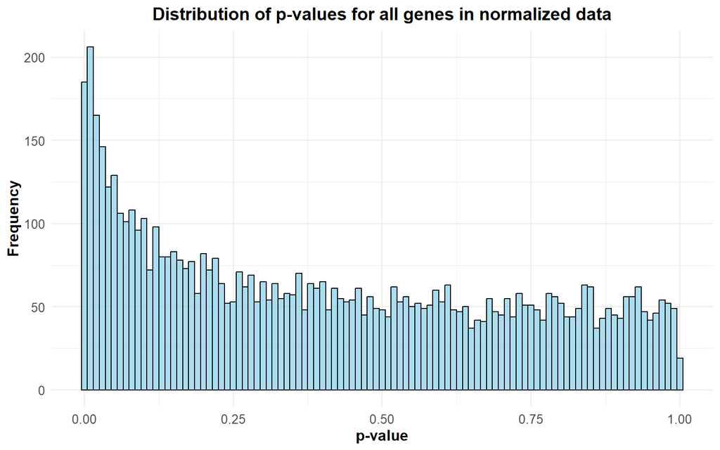

```r
ggplot(gene_pvalues2, aes(x = p_value)) +
  geom_histogram(binwidth = 0.01, fill = "skyblue", color = "black", alpha = 0.7) +
  labs(title = "Distribution of p-values for all genes in normalized data", x = "p-value", y = "Frequency") +
  theme_minimal() +
  theme(plot.title = element_text(size = 14, face = "bold", hjust = 0.5),
        axis.title = element_text(size = 12, face = "bold"),
        axis.text = element_text(size = 10))
```

The code below performs the linear models of the gene with the most and least significant effects in the normalized dataset.

```r
#Create models for most and least significant genes
most_signif_model2 <- lm(age ~ Expression, data = RNAseq_GSE248274_norm2[RNAseq_GSE248274_norm2$SYMBOL == most_signif2[1, "SYMBOL"], ])
least_signif_model2 <- lm(age ~ Expression, data = RNAseq_GSE248274_norm2[RNAseq_GSE248274_norm2$SYMBOL == least_signif2[1, "SYMBOL"], ])
```

The code below present the model summary and ANOVA results for the linear models of the gene with the most significant effects in the normalized dataset.

```r
summary(most_signif_model2)
```

```
##
## Call:
## lm(formula = age ~ Expression, data = RNAseq_GSE248274_norm2[RNAseq_GSE248274_norm2$SYMBOL ==
##     most_signif2[1, "SYMBOL"], ])
##
## Residuals:
##     Min      1Q  Median      3Q     Max
## -6.4136 -1.5646 -0.5950  0.9397  8.8292
##
## Coefficients:
##             Estimate Std. Error t value Pr(>|t|)
## (Intercept) 50.96797    1.78050   28.63 2.05e-12 ***
## Expression   0.42990    0.04211   10.21 2.87e-07 ***
## ---
## Signif. codes:  0 '***' 0.001 '**' 0.01 '*' 0.05 '.' 0.1 ' ' 1
##
## Residual standard error: 3.627 on 12 degrees of freedom
##   (14 observations deleted due to missingness)
## Multiple R-squared:  0.8967, Adjusted R-squared:  0.8881
## F-statistic: 104.2 on 1 and 12 DF,  p-value: 2.866e-07
```

```r
anova(most_signif_model2)
```

```
## Analysis of Variance Table
##
## Response: age
##            Df  Sum Sq Mean Sq F value    Pr(>F)
## Expression  1 1370.53 1370.53   104.2 2.866e-07 ***
## Residuals  12  157.83   13.15
## ---
## Signif. codes:  0 '***' 0.001 '**' 0.01 '*' 0.05 '.' 0.1 ' ' 1
```

The code below present the model summary and ANOVA results for the linear models of the gene with the least significant effects in the normalized dataset.

```r
summary(least_signif_model2)
```

```
##
## Call:
## lm(formula = age ~ Expression, data = RNAseq_GSE248274_norm2[RNAseq_GSE248274_norm2$SYMBOL ==
##     least_signif2[1, "SYMBOL"], ])
##
## Residuals:
##     Min      1Q  Median      3Q     Max
## -11.214  -8.214  -2.214   4.036  21.786
##
## Coefficients:
##               Estimate Std. Error t value Pr(>|t|)
## (Intercept)  6.621e+01  6.609e+00   10.02 3.51e-07 ***
## Expression  -4.896e-08  1.227e-03    0.00        1
## ---
## Signif. codes:  0 '***' 0.001 '**' 0.01 '*' 0.05 '.' 0.1 ' ' 1
##
## Residual standard error: 11.29 on 12 degrees of freedom
##   (14 observations deleted due to missingness)
## Multiple R-squared:  1.326e-10,  Adjusted R-squared:  -0.08333
## F-statistic: 1.592e-09 on 1 and 12 DF,  p-value: 1
```

```r
anova(least_signif_model2)
```

```
## Analysis of Variance Table
##
## Response: age
##            Df Sum Sq Mean Sq F value Pr(>F)
## Expression  1    0.0    0.00       0      1
## Residuals  12 1528.4  127.36
```

The code below generates the diagnostic plots for the linear models of the gene with the most significant effects.

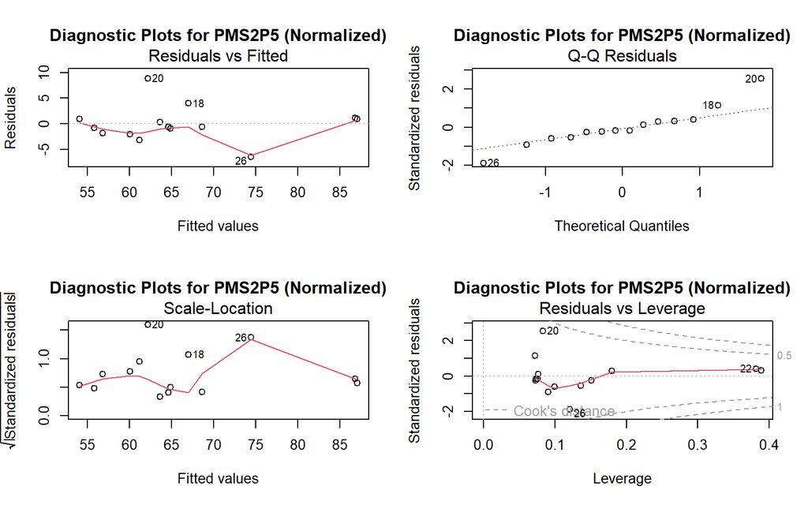

```r
par(mfrow = c(2, 2))
plot(most_signif_model2, main = paste("Diagnostic Plots for", most_signif2[1, "SYMBOL"], "(Normalized)"))
```

The code below generates the diagnostic plots for the linear models of the gene with the least significant effects.

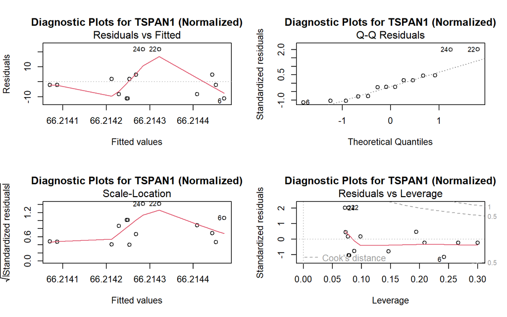

```r
par(mfrow = c(2, 2))
plot(least_signif_model2, main = paste("Diagnostic Plots for", least_signif2[1, "SYMBOL"], "(Normalized)"))
```

**Explanation of Results**

Discussion on the most significant genes, PMSC4 (raw) and PMS2P5 (normalized) data:

Based on the residuals vs. fitted plots of PSMC4 (raw data) and PMS2P5 (normalized), both plots doesn’t show a clear pattern which indicates non-linear relationships between the dependent and independent variables. In this case, the model was able to capture the linear relationship. However, data points #2 & 12 are pointed out in the PSMC4 9 (raw) data set, and data point #20 is shown to be the farthest in PMS2P5 (normalized) data set.

The Q-Q plots show that both PMSC4 (raw) and PMS2P5 (normalized) data look quite normally distributed. Although one can see that PMS2P5 (normalized) data have a couple data points (#20 & 26) that are a bit further off the straight line, which could be a potential problem. There are also outliers, #2 & 12, away from the straight line in the PMSC4 (raw) data set.

The Scale-LOcation plot checks for the assumption of equal variance (homoscedasticity). Both plots for PMSC4 (raw) and PMS2P5 (normalized) data show an equally random spread of data points indicating good, equal variance (for the most part). Although, we see again data point #20 in PMS2P5 (normalized) data has the widest spread. Whereas, #2 & 12 are seen again in this plot to have a wider spread in PMSC4 (raw) data set.

Seeing the outliers that have been consistent across the plots within each data set, the residuals vs. leverage plots helps to determine whether these data points are influential and does not follow the trend. It seems that data points #2 & 12, in PMSC4 (raw) data set, are influential to the regression results because they have a high Cook’s distance score as they touch the dashed line. Within PMS2P5 (normalized) data set, data point #20 reach close to the Cook’s distance line, also indicating that it might be influential to the regression.

Therefore, for the most significant gene: PMSC4 (raw) data set, the four plots show potential problematic cases with two data points that is influential to the regression analysis and probably needs a closer look individually whether there is really a linear relationship between the dependent and independent variables. If so, perhaps *age* may not be the best variable to represent the model of the differential gene expression. In comparison, PMS2P5 (normalized) data set is the *better* data set because it improved upon the previous by having only one problematic data point that could be influential to the regression; However, the fact that four plots show the consistent, problematic data point may warrant further look into the data.

Discussion on the least significant genes, PCSK9 (raw) and TSPAN1 (normalized) data:

In both cases, raw and normalized data does not show any distinctive pattern in the residual vs. fitted values plots. The Q-Q plots show close enough to a normal distribution in both data sets, however both also show 3 outliers each, away from the straight line that could be problematic. The Scale-Location for PCSK9 (raw) data does not show homoscedasticity, while TSPAN1 (normalized) data show better equal (randomly) spread points. Finally, PCSK9 (raw) plot of residuals vs. leverage show more data points with a high Cook’s distance indicating the problematic outliers seen in previous plots could be influential to the linear regression. Whereas, TSPAN1 (normalized) plot does not show data points that is really close to Cook’s distance, indicating any outliers observed in previous plots may not be as influential/problematic to the linear regression. Based on these observations, the normalized data again proves to be the *better* dataset to create models to study the relationship between age and gene expression in this study.

# 3 Question 3

## 3.1 The relationship between the fitted and residual values of the most significant gene to the dependent variable.

Using the gene with the greatest association to the dependent variable (in this case, age), the code below obtains the associated data and creates a new data frame for plotting.

```r
# Get the most significant gene's data
most_sig_gene <- most_signif2[1, "SYMBOL"]
gene_data <- RNAseq_GSE248274_norm2[RNAseq_GSE248274_norm2$SYMBOL == most_sig_gene, ]
# Clean up the data
gene_data <- gene_data[!is.na(gene_data$age), ]

# Fit the model
fit_model <- lm(age ~ Expression, data = gene_data)

# Get predicted (fitted) values
fitted_values <- predict(fit_model)
# Get observed values
obsvd_values <- gene_data$age
# Get residuals
resid_values <- resid(fit_model)

# Create a data frame for plotting
new_df3 <- data.frame(
  Expression = gene_data$Expression,
  Observed = obsvd_values,
  Fitted = fitted_values,
  Residuals = resid_values
)
head(new_df3)
```

```
##   Expression Observed   Fitted  Residuals
## 1  23.689446       58 61.15200 -3.1520021
## 2  21.135240       58 60.05396 -2.0539555
## 3  13.557570       55 56.79633 -1.7963347
## 4   7.173807       55 54.05197  0.9480284
## 5  11.199143       55 55.78245 -0.7824530
## 6  31.676150       64 64.58547 -0.5854655
```

The code below will create plots between the fitted data and the observed values, and between the fitted data and the residual values.

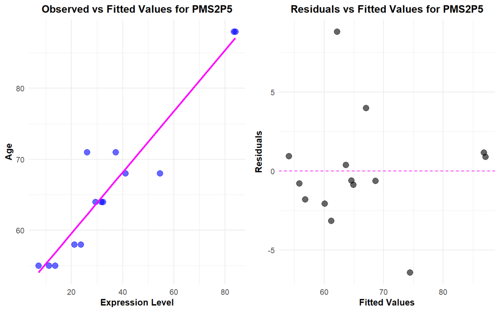

```r
# Plot 1: Observed vs Fitted values with regression line
plot1 <- ggplot(new_df3, aes(x = Expression)) +
  geom_point(aes(y = Observed), color = "blue", size = 3, alpha = 0.6) +
  geom_line(aes(y = Fitted), color = "magenta", linewidth = 1) +
  labs(title = paste("Observed vs Fitted Values for", most_sig_gene),
       x = "Expression Level",
       y = "Age") +
  theme_minimal() +
  theme(plot.title = element_text(size = 12, face = "bold", hjust = 0.5),
        axis.title = element_text(size = 10, face = "bold"))

# Plot 2: Residuals vs Fitted values
plot2 <- ggplot(new_df3, aes(x = Fitted, y = Residuals)) +
  geom_point(color = "black", size = 3, alpha = 0.6) +
  geom_hline(yintercept = 0, linetype = "dashed", color = "magenta") +
  labs(title = paste("Residuals vs Fitted Values for", most_sig_gene),
       x = "Fitted Values",
       y = "Residuals") +
  theme_minimal() +
  theme(plot.title = element_text(size = 12, face = "bold", hjust = 0.5),
        axis.title = element_text(size = 10, face = "bold"))

# Arrange plots side by side
#dev.off() #optional in case of invalid graphics state
plot_grid(plot1, plot2, ncol = 2)
```

The following code will print the summary statistics of the Observed vs. Expression plot.

```r
# Print summary statistics
cat("Summary Statistics for most significant gene,", most_sig_gene, ":\n", "Correlation between Observed and Fitted values =", cor(obsvd_values, fitted_values), "\n", "Mean Absolute Error =", mean(abs(resid_values)), "\n", "Root Mean Square Error =", sqrt(mean(resid_values^2)), "\n")
```

```
## Summary Statistics for most significant gene, PMS2P5 :
##  Correlation between Observed and Fitted values = 0.9469597
##  Mean Absolute Error = 2.322529
##  Root Mean Square Error = 3.357607
```